# Medidas de tendencia central

[DE ANDA ZAVALA VALERIA SARAI](https://vsdeanz.github.io)

Estadística 2022-2, [Facultad de economía](http://www.economia.unam.mx/)

2/3/2022

### 1. ¿Qué son las medidas de tendencia central? 🤔

> Definición: “las medidas de tendencia central sirven para conocer en qué lugar se ubica el elemento promedio, o típico del grupo. Asimismo, las medidas de tendencia central sirven para comparar, así como para interpretar los resultados obtenido con relación a los distintos valores observados. También, las medidas de tendencia central sirven para comparar e interpretar el valor de una misma variable en distintas ocasiones. Imaginemos que valor medio de una variable no es representativa, por lo que podemos complementar con el valor mediano para extraer una imagen fiel.”

[Economipedia (2019)](https://economipedia.com/definiciones/medidas-de-tendencia-central.html)

Para este ejemplo, primero generaremos una serie de **100** números aleatorios entre **1** y **20** mediante la función `sample`. El argumento `TRUE` nos permitirá generar una muestra con remplazo:

```r
numeros <- sample(1:20, 100, TRUE)
numeros
```

```
##   [1] 11 13  2 20 11 18  3 12 18  9 10  4 16 18 19 11 15  2  4 18  9  3 17  8 16
##  [26] 18  7  6 15  1 17 20  7  8  8  4  3 13 11 11  6  3 20 11  1  4 14 14 15 12
##  [51] 11  2 13 14 13 15 14 20 10 16 13  8  2  9 11 19  5 16  2  9  8 16 14  8 14
##  [76] 17 16  9 12 17 18 20 18  2 15 15 13 16 19 12 13  8 11 10  8 11 10 13  1 19
```

### 2. Mediana 📍

> Definición: “En el ámbito de la [estadística](https://es.wikipedia.org/wiki/Estad%C3%ADstica), la **mediana** (del latín *mediānus* ‘del medio’<sup>1</sup>) representa el valor de la variable de posición central en un conjunto de datos ordenados. Se le denota **mediana**.Si la serie tiene un número par de puntuaciones, la mediana es la media entre las dos puntuaciones centrales.”

wikipedia (2022)

Para obtener la **mediana**, podemos ordenar los `numeros` de menor a mayor, **el número que esté en medio de la muestra será la mediana**. Si utilizamos R, se puede hacer el cálculo de la **mediana** con la función `median`:

```r
mediana <- median(numeros)
mediana
```

```
## [1] 12
```

### 3. Media 🧮

> Definición: “**La media es el valor promedio de un conjunto de datos numéricos, calculada como la suma del conjunto de valores dividida entre el número total de valores.**”

[Economipedia (2018)](https://economipedia.com/definiciones/media.html#:~:text=La%20media%20es%20el%20valor,matem%C3%A1tica%2C%20es%20un%20t%C3%A9rmino%20matem%C3%A1tico.)

$$Media ={\frac {1}{n}}\sum _{i=1}^{n}a_{i}={\frac {a_{1}+a_{2}+\cdots +a_{n}}{n}}$$

Si usamos R, podemos obtener la media de una muestra si utlilizamos la función **mean**:

```r
media <- mean(numeros)
media
```

```
## [1] 11.41
```

### 4. Moda 📊

Podemos saber cuál es la **frecuencia** (número de veces que aparece un elemento en una muestra) de cada número si dibujamos un **histograma** con la función `hist`, **aquel elemento con mayor frecuencia será la moda**:

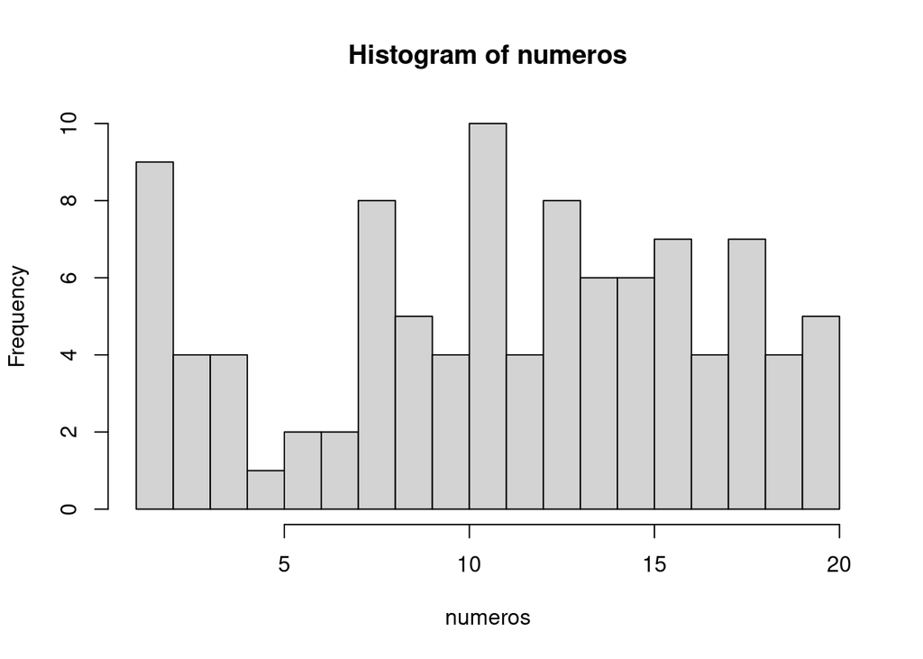

```r
# El argumento breaks nos permite dividir en histograma en las partes que queramos
hist(numeros, breaks = 20)
```

Para obtener un resultado con más precisión, podemos obtener la **moda** si generamos una **tabla de frecuencias** con la función `table` y la función `data.frame`, **aquel elemento con mayor frecuencia será la moda**:

```r
tabla.frecuencias <- data.frame(table(numeros))
tabla.frecuencias
```

```
##    numeros Freq
## 1        1    3
## 2        2    6
## 3        3    4
## 4        4    4
## 5        5    1
## 6        6    2
## 7        7    2
## 8        8    8
## 9        9    5
## 10      10    4
## 11      11   10
## 12      12    4
## 13      13    8
## 14      14    6
## 15      15    6
## 16      16    7
## 17      17    4
## 18      18    7
## 19      19    4
## 20      20    5
```

### 5. Ejercicio 👩‍💻👨‍💻✍

Aplica lo que aprendiste, obten la **mediana**, **media** y **moda** de la siguiente muestra de números:

```r
# Con la función seq, creamos una secuencia de 1 a 10 en intervalos de 0.1 en 0.1
secuencia <- seq(1, 10, 0.1)
muestra <- sample(secuencia, 100, TRUE)
muestra
```

```
##   [1]  1.0  8.9  3.3  5.4  8.8  9.4  5.3  8.8  8.3  8.9  7.1 10.0  5.4  5.0  8.5
##  [16]  6.6  5.6  1.0  5.8  7.0  7.2  4.1  9.1  9.4  8.5  7.0  4.8  9.3  9.6  2.1
##  [31]  7.5  7.4  5.0  4.2  7.4  1.5  5.5  6.0  1.6  8.6  2.1  8.0  2.5  4.8  9.4
##  [46]  4.2  9.8  8.7  3.7  6.0  1.6  9.2  5.7  8.4  3.2  7.8  6.8  9.5  7.6  1.1
##  [61]  3.3  5.6  7.6  8.1  5.2  6.7  3.2  4.1  9.7  2.9  4.6  3.7  6.3  2.2  9.0
##  [76]  2.2  6.5  1.7  3.5  7.7  3.0  5.4  1.5  1.1  9.7  1.2  6.1  5.8  9.1  4.7
##  [91]  7.4  4.0  9.7  3.9  9.6  4.9  4.8  7.6  4.8  1.1
```

##### Mediana

```r
# Aquí el cálculo de la mediana
mediana.muestra <- median(muestra)
mediana
```

[output not shown]

[output not shown]

##### Media

```r
# Aquí el cálculo de la media
media.muestra <- mean(muestra)
media.muestra
```

```
## [1] 5.852
```

##### Moda

```r
# Aquí el cálculo de la moda
tabla.frecuencias <- data.frame(table(muestra))
tabla.frecuencias
```

```
##    muestra Freq
## 1        1    2
## 2      1.1    3
## 3      1.2    1
## 4      1.5    2
## 5      1.6    2
## 6      1.7    1
## 7      2.1    2
## 8      2.2    2
## 9      2.5    1
## 10     2.9    1
## 11       3    1
## 12     3.2    2
## 13     3.3    2
## 14     3.5    1
```

[output cut: 51 more lines]

💻[Código disponible en RStudio Cloud](https://rstudio.cloud/project/3671022)💻